# **TÉCNICAS DE OPTIMIZACIÓN DE REDES CONVOLUCIONALES**

```python
%%capture

!jupyter nbconvert --to html RedesConvolucionales.ipynb
```

```python
#Librerías necesarias
from google.colab import drive
from keras import layers
from keras import models
from keras import optimizers
from keras.preprocessing.image import ImageDataGenerator
import matplotlib.pyplot as plt
import numpy as np
import os
import pandas as pd
import seaborn as sns
from sklearn.metrics import confusion_matrix
import tensorflow as tf
```

```python
#Para acceder a los ficheros de drive
drive.mount('/content/gdrive')
#Listamos los ficheros existentes en el directorio raiz
#!ls "/content/gdrive/MyDrive"
```

Carga de los datos de entrenamiento, validación y test.

```python
base_dir='/content/gdrive/MyDrive/dest_folder'
print(base_dir)
train_dir = os.path.join(base_dir, 'train')
print(train_dir)
val_dir = os.path.join(base_dir, 'val')
print(val_dir)
test_dir = os.path.join(base_dir, 'test')
print(test_dir)
# Entrenamiento
train_withmask_dir = os.path.join(train_dir, 'with_mask')
train_withoutmask_dir = os.path.join(train_dir, 'without_mask')
# Validacion
val_withmask_dir = os.path.join(val_dir, 'with_mask')
val_withoutmask_dir = os.path.join(val_dir, 'without_mask')
# Test
test_withmask_dir = os.path.join(test_dir, 'with_mask')
test_withoutmask_dir = os.path.join(test_dir, 'without_mask')
```

```
/content/gdrive/MyDrive/dest_folder
/content/gdrive/MyDrive/dest_folder/train
/content/gdrive/MyDrive/dest_folder/val
/content/gdrive/MyDrive/dest_folder/test
```

Se hace una rápida comprobación de que todo está cargado correctamente. Se han eliminado duplicados de los datos de test manualmente.

```python
print('Total de entrenamiento con máscara:', len(os.listdir(train_withmask_dir)))
print('Total de entrenamiento sin máscara:', len(os.listdir(train_withoutmask_dir)))
print('Total de validación con máscara:', len(os.listdir(val_withmask_dir)))
print('Total de validación sin máscara:', len(os.listdir(val_withoutmask_dir)))
print('Total de test con máscara:', len(os.listdir(test_withmask_dir)))
print('Total de test sin máscara:', len(os.listdir(test_withoutmask_dir)))
```

```
Total de entrenamiento con máscara: 658
Total de entrenamiento sin máscara: 657
Total de validación con máscara: 71
Total de validación sin máscara: 71
Total de test con máscara: 97
Total de test sin máscara: 97
```

## AUMENTO DE LA MUESTA Y REGULARIZACIÓN DROPOUT

La primera técnica de optimización consiste en aumentar la muestra mediante la aplicación de transformaciones sobre los datos de entrenamiento. En este caso, se aplican de manera aleatoria las siguientes transformaciones:

- Traslaciones
- Homotecias
- Simetrías horizontales (las verticales no tienen sentido para imágenes de caras)

Antes de poder entrenar el modelo, es necesario convertir las imágenes en formato JPEG en tensores. Siguiendo a Chollet, los pasos a seguir son los siguiente:

- Decodificar las imágenes en formato JPEG en un grid RGB
- Convertir el grid anterior en tensores
- Normalizar los datos mediante una homotecia que transforme el intervalo [0,255] al intervalo [0,1]

Todo esto se puede hacer de manera sencilla en tensorflow, con las siguientes instrucciones:

```python
# semilla para reproducir los resultados
seed=339
np.random.seed(seed)
tf.random.set_seed(seed)

train_datagen = ImageDataGenerator(rescale=1./255,
                                   rotation_range=45,
                                   width_shift_range=0.2,
                                   height_shift_range=0.2,
                                   shear_range=0.15,
                                   zoom_range=0.1,
                                   horizontal_flip=True
                                   )
val_datagen = ImageDataGenerator(rescale=1./255)
test_datagen = ImageDataGenerator(rescale=1./255)

batch_size = 32
alto, ancho = 150, 150
canal = 3

train_generator = train_datagen.flow_from_directory(
train_dir,
target_size=(alto, ancho),
batch_size=batch_size,
class_mode='binary')

validation_generator = val_datagen.flow_from_directory(
val_dir,
target_size=(alto, ancho),
batch_size=batch_size,
class_mode='binary')



test_generator = test_datagen.flow_from_directory(
test_dir,
target_size=(alto, ancho),
batch_size=batch_size,
class_mode='binary')
```

```
Found 1315 images belonging to 2 classes.
Found 142 images belonging to 2 classes.
Found 194 images belonging to 2 classes.
```

Recorremos los tensores para ver su estructura y que la carga ha ido correctamente:

```python
for data_batch, labels_batch in train_generator:
    print('data batch shape:', data_batch.shape)
    print('labels batch shape:', labels_batch.shape)
    break
```

```
data batch shape: (32, 150, 150, 3)
labels batch shape: (32,)
```

Red neuronal con los datos aumentados.

```python
# Estructura lineal
cnn_regu_dropout = tf.keras.Sequential()
# Primera capa de  convolución
cnn_regu_dropout.add(tf.keras.layers.Conv2D(16,
                            (3,3),
                            activation='relu', input_shape=(alto, ancho, canal)))
cnn_regu_dropout.add(tf.keras.layers.MaxPooling2D((2, 2)))

# Segunda capa de  convolución
cnn_regu_dropout.add(tf.keras.layers.Conv2D(32,
                            (3,3),
                            activation='relu', input_shape=(alto, ancho, canal)))
cnn_regu_dropout.add(tf.keras.layers.MaxPooling2D((2, 2)))
cnn_regu_dropout.add(tf.keras.layers.Dropout(0.25))

# Tercera capa de  convolución
cnn_regu_dropout.add(tf.keras.layers.Conv2D(64,
                            (3,3),
                            activation='relu', input_shape=(alto, ancho, canal)))
cnn_regu_dropout.add(tf.keras.layers.MaxPooling2D((2, 2)))
cnn_regu_dropout.add(tf.keras.layers.Dropout(0.25))

# Cuarta capa de  convolución
cnn_regu_dropout.add(tf.keras.layers.Conv2D(128,
                            (3,3),
                            activation='relu', input_shape=(alto, ancho, canal)))
cnn_regu_dropout.add(tf.keras.layers.MaxPooling2D((2, 2)))


cnn_regu_dropout.add(tf.keras.layers.Flatten())
cnn_regu_dropout.add(layers.Dense(256, activation='relu'))
cnn_regu_dropout.add(tf.keras.layers.Dense(1, activation='sigmoid'))
```

Ésta es la estructura de la red neuronal, con cuatro capas de convolución-pooling y dos capas de dropout.

```python
cnn_regu_dropout.summary()
```

```
Model: "sequential_1"
_________________________________________________________________
Layer (type)                 Output Shape              Param #
=================================================================
conv2d_4 (Conv2D)            (None, 148, 148, 16)      448
_________________________________________________________________
max_pooling2d_4 (MaxPooling2 (None, 74, 74, 16)        0
_________________________________________________________________
conv2d_5 (Conv2D)            (None, 72, 72, 32)        4640
_________________________________________________________________
max_pooling2d_5 (MaxPooling2 (None, 36, 36, 32)        0
_________________________________________________________________
dropout_2 (Dropout)          (None, 36, 36, 32)        0
_________________________________________________________________
conv2d_6 (Conv2D)            (None, 34, 34, 64)        18496
_________________________________________________________________
max_pooling2d_6 (MaxPooling2 (None, 17, 17, 64)        0
_________________________________________________________________
dropout_3 (Dropout)          (None, 17, 17, 64)        0
_________________________________________________________________
conv2d_7 (Conv2D)            (None, 15, 15, 128)       73856
_________________________________________________________________
max_pooling2d_7 (MaxPooling2 (None, 7, 7, 128)         0
_________________________________________________________________
flatten_1 (Flatten)          (None, 6272)              0
_________________________________________________________________
module_wrapper_1 (ModuleWrap (None, 256)               1605888
_________________________________________________________________
dense_1 (Dense)              (None, 1)                 257
=================================================================
Total params: 1,703,585
Trainable params: 1,703,585
Non-trainable params: 0
_________________________________________________________________
```

```python
cnn_regu_dropout.compile(loss='binary_crossentropy',
optimizer='rmsprop',
metrics=['accuracy'])
```

Entrenamos el modelo con unas pocas épocas para evitar el sobreajuste.

```python
epocas = 10

steps_per_epoch = train_generator.n // batch_size
validation_steps = validation_generator.n // batch_size

history = cnn_regu_dropout.fit(train_generator,
                               steps_per_epoch=steps_per_epoch,
                               epochs=epocas,
                               validation_data=validation_generator,
                               validation_steps=validation_steps)
```

Investigamos si existe sobreajuste mediante un análisis gráfico.

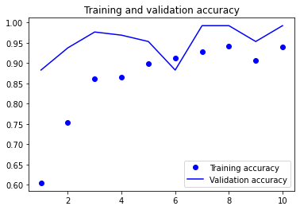

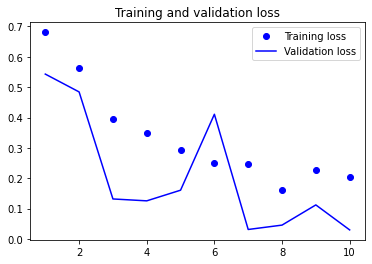

```python
# construcción de un data.frame
accuracy = history.history['accuracy']
val_accuracy = history.history['val_accuracy']
loss = history.history['loss']
val_loss = history.history['val_loss']
epochs = range(1, len(accuracy) + 1)
plt.plot(epochs, accuracy, 'bo', label='Training accuracy')
plt.plot(epochs, val_accuracy, 'b', label='Validation accuracy')
plt.title('Training and validation accuracy')
plt.legend()
plt.figure()
plt.plot(epochs, loss, 'bo', label='Training loss')
plt.plot(epochs, val_loss, 'b', label='Validation loss')
plt.title('Training and validation loss')
plt.legend()
plt.show()
```

No parece haber sobreajuste con tan pocas épocas, al tiempo que se consigue un buen ajuste. Comprobamos esta última afirmación probando sobre los datos de test.

```python
#cnn_regu_dropout.save('/content/gdrive/MyDrive/ModelosConvolucional/cnn_regu_dropout')
#new_model = tf.keras.models.load_model('/content/gdrive/MyDrive/ModelosConvolucional/cnn_regu_dropout')
```

Matriz de confusión sobre los datos de validación.

```
Evaluación accuracy: 99.30%
```

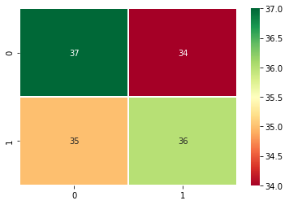

```python
validation_generator.reset()

# Evaluación del modelo en la muestra de Validation -> muestra total
scores = cnn_regu_dropout.evaluate(validation_generator)
print("%s%s: %.2f%%" % ("Evaluación ", cnn_regu_dropout.metrics_names[1], scores[1]*100))

# model_tf_hub.metrics_names  -> [0]: loss [1]: accuracy

# predicciones de las instancias
predictions_proba = cnn_regu_dropout.predict(validation_generator)
predictions_class = np.where(predictions_proba > 0.5, 1, 0)

# matriz de confusión
sns.heatmap(confusion_matrix(validation_generator.labels, predictions_class), cmap="RdYlGn", linewidths=.5,
            annot = True,  fmt='.0f', cbar=True)

plt.show()
```

Matriz de confusión sobre los datos de test.

```
Evaluación accuracy: 97.94%
```

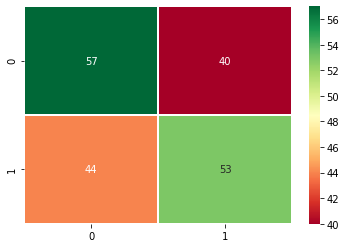

```python
# Evaluación del modelo en la muestra de Validation -> muestra total
scores = cnn_regu_dropout.evaluate(test_generator)
scores
print("%s%s: %.2f%%" % ("Evaluación ", cnn_regu_dropout.metrics_names[1], scores[1]*100))

# model_tf_hub.metrics_names  -> [0]: loss [1]: accuracy

# predicciones de las instancias
predictions_proba = cnn_regu_dropout.predict(test_generator)
predictions_class = np.where(predictions_proba >0.5, 1, 0)

#matriz de confusión
sns.heatmap(confusion_matrix(test_generator.labels, predictions_class), cmap="RdYlGn", linewidths=.5,
             annot = True,  fmt='.0f', cbar=True)

plt.show()
```

Puesto que se consigue una precisión acorde a los datos de validación, descartamos el sobreajuste en el entrenamiento del modelo.

# Optimización usando algoritmos preentrenados

La idea de este algoritmo es usar los patrones aprendidos por otras redes convolucionales ya entrenadas y usar ese conocimiento para nuestro problema específico. Para ello, a la base convolucional del modelo ya entrenado, se añade una capa densa adaptada a nuestro problema de clasificación concreto.

Usaremos la red VGG16.

```python
VGG16 = tf.keras.applications.VGG16(include_top=False, input_shape=(alto, ancho, canal), weights='imagenet')
```

Configuramos una nueva red para que su base no sea entrenable y añadimos una red densa sobre la base de VGG16 adaptada a nuestro problema de clasificación.

```python
VGG16.trainable = False

cnn_VGG16_ft = tf.keras.Sequential()
cnn_VGG16_ft.add(VGG16)
cnn_VGG16_ft.add(tf.keras.layers.Flatten())
cnn_VGG16_ft.add(tf.keras.layers.Dense(16, activation='relu'))
cnn_VGG16_ft.add(tf.keras.layers.Dropout(0.50))
cnn_VGG16_ft.add(tf.keras.layers.Dense(1, activation='sigmoid'))
```

```python
cnn_VGG16_ft.summary()
```

```
Model: "sequential_6"
_________________________________________________________________
Layer (type)                 Output Shape              Param #
=================================================================
vgg16 (Functional)           (None, 4, 4, 512)         14714688
_________________________________________________________________
flatten_6 (Flatten)          (None, 8192)              0
_________________________________________________________________
dense_12 (Dense)             (None, 16)                131088
_________________________________________________________________
dropout_6 (Dropout)          (None, 16)                0
_________________________________________________________________
dense_13 (Dense)             (None, 1)                 17
=================================================================
Total params: 14,845,793
Trainable params: 131,105
Non-trainable params: 14,714,688
_________________________________________________________________
```

```python
cnn_VGG16_ft.compile(loss='binary_crossentropy',
optimizer=optimizers.RMSprop(learning_rate=2e-5),
metrics=['accuracy'])
```

Entrenamos el modelo con unas pocas épocas con la esperanza de no sobreentrenar el modelo.

```python
validation_generator.reset()

epocas = 15

steps_per_epoch = train_generator.n // batch_size
validation_steps = validation_generator.n // batch_size

history = cnn_VGG16_ft.fit(train_generator,
                               steps_per_epoch=steps_per_epoch,
                               epochs=epocas,
                               validation_data=validation_generator,
                               validation_steps=validation_steps)
```

```python
#cnn_VGG16_ft.save('/content/gdrive/MyDrive/ModelosConvolucional/cnn_VGG16_ft')
```

Plot para ver la diferencia gráfica entre los datos de validación y entrenamiento,

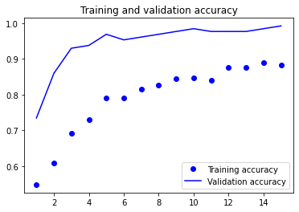

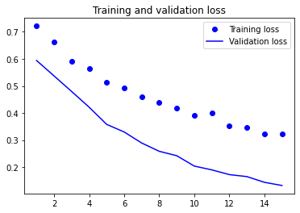

```python
accuracy = history.history['accuracy']
val_accuracy = history.history['val_accuracy']
loss = history.history['loss']
val_loss = history.history['val_loss']
epochs = range(1, len(accuracy) + 1)
plt.plot(epochs, accuracy, 'bo', label='Training accuracy')
plt.plot(epochs, val_accuracy, 'b', label='Validation accuracy')
plt.title('Training and validation accuracy')
plt.legend()
plt.figure()
plt.plot(epochs, loss, 'bo', label='Training loss')
plt.plot(epochs, val_loss, 'b', label='Validation loss')
plt.title('Training and validation loss')
plt.legend()
plt.show()
```

Matriz de confusión para los datos de validación.

```
Evaluación accuracy: 98.59%
```

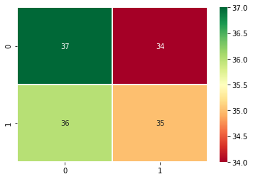

```python
validation_generator.reset()

# Evaluación del modelo en la muestra de Validation -> muestra total
scores = cnn_VGG16_ft.evaluate(validation_generator)
print("%s%s: %.2f%%" % ("Evaluación ", cnn_VGG16_ft.metrics_names[1], scores[1]*100))

# model_tf_hub.metrics_names  -> [0]: loss [1]: accuracy

# predicciones de las instancias
predictions_proba = cnn_VGG16_ft.predict(validation_generator)
predictions_class = np.where(predictions_proba > 0.5, 1, 0)

# matriz de confusión
sns.heatmap(confusion_matrix(validation_generator.labels, predictions_class), cmap="RdYlGn", linewidths=.5,
            annot = True,  fmt='.0f', cbar=True)

plt.show()
```

Matriz de confusión para los datos de test.

```
Evaluación accuracy: 98.45%
```

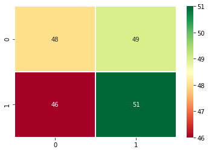

```python
# Evaluación del modelo en la muestra de Validation -> muestra total
scores = cnn_VGG16_ft.evaluate(test_generator)
print("%s%s: %.2f%%" % ("Evaluación ", cnn_VGG16_ft.metrics_names[1], scores[1]*100))

# model_tf_hub.metrics_names  -> [0]: loss [1]: accuracy

# predicciones de las instancias
predictions_proba = cnn_VGG16_ft.predict(test_generator)
predictions_class = np.where(predictions_proba >0.5, 1, 0)

#matriz de confusión
sns.heatmap(confusion_matrix(test_generator.labels, predictions_class), cmap="RdYlGn", linewidths=.5,
             annot = True,  fmt='.0f', cbar=True)

plt.show()
```

La red muestra una precisión muy próxima a los datos de validación

## FINE TUNING

Usaremos la red XCeption, la cual tiene una estructura un poco diferente a las redes convolucionales estudiadas en el curso.

```python
Xception = tf.keras.applications.Xception(include_top=False, input_shape=(alto, ancho, canal), weights='imagenet')
```

```python
Xception.summary()
```

```
Model: "xception"
__________________________________________________________________________________________________
Layer (type)                    Output Shape         Param #     Connected to
==================================================================================================
input_3 (InputLayer)            [(None, 150, 150, 3) 0
__________________________________________________________________________________________________
block1_conv1 (Conv2D)           (None, 74, 74, 32)   864         input_3[0][0]
__________________________________________________________________________________________________
block1_conv1_bn (BatchNormaliza (None, 74, 74, 32)   128         block1_conv1[0][0]
__________________________________________________________________________________________________
block1_conv1_act (Activation)   (None, 74, 74, 32)   0           block1_conv1_bn[0][0]
__________________________________________________________________________________________________
block1_conv2 (Conv2D)           (None, 72, 72, 64)   18432       block1_conv1_act[0][0]
__________________________________________________________________________________________________
block1_conv2_bn (BatchNormaliza (None, 72, 72, 64)   256         block1_conv2[0][0]
__________________________________________________________________________________________________
block1_conv2_act (Activation)   (None, 72, 72, 64)   0           block1_conv2_bn[0][0]
__________________________________________________________________________________________________
block2_sepconv1 (SeparableConv2 (None, 72, 72, 128)  8768        block1_conv2_act[0][0]
__________________________________________________________________________________________________
block2_sepconv1_bn (BatchNormal (None, 72, 72, 128)  512         block2_sepconv1[0][0]
__________________________________________________________________________________________________
block2_sepconv2_act (Activation (None, 72, 72, 128)  0           block2_sepconv1_bn[0][0]
__________________________________________________________________________________________________
block2_sepconv2 (SeparableConv2 (None, 72, 72, 128)  17536       block2_sepconv2_act[0][0]
__________________________________________________________________________________________________
block2_sepconv2_bn (BatchNormal (None, 72, 72, 128)  512         block2_sepconv2[0][0]
__________________________________________________________________________________________________
conv2d_4 (Conv2D)               (None, 36, 36, 128)  8192        block1_conv2_act[0][0]
__________________________________________________________________________________________________
block2_pool (MaxPooling2D)      (None, 36, 36, 128)  0           block2_sepconv2_bn[0][0]
__________________________________________________________________________________________________
batch_normalization_4 (BatchNor (None, 36, 36, 128)  512         conv2d_4[0][0]
__________________________________________________________________________________________________
add_12 (Add)                    (None, 36, 36, 128)  0           block2_pool[0][0]
                                                                 batch_normalization_4[0][0]
__________________________________________________________________________________________________
block3_sepconv1_act (Activation (None, 36, 36, 128)  0           add_12[0][0]
__________________________________________________________________________________________________
block3_sepconv1 (SeparableConv2 (None, 36, 36, 256)  33920       block3_sepconv1_act[0][0]
```

[output cut: 229 more lines]

```
__________________________________________________________________________________________________
block14_sepconv1_bn (BatchNorma (None, 5, 5, 1536)   6144        block14_sepconv1[0][0]
__________________________________________________________________________________________________
block14_sepconv1_act (Activatio (None, 5, 5, 1536)   0           block14_sepconv1_bn[0][0]
__________________________________________________________________________________________________
block14_sepconv2 (SeparableConv (None, 5, 5, 2048)   3159552     block14_sepconv1_act[0][0]
__________________________________________________________________________________________________
block14_sepconv2_bn (BatchNorma (None, 5, 5, 2048)   8192        block14_sepconv2[0][0]
__________________________________________________________________________________________________
block14_sepconv2_act (Activatio (None, 5, 5, 2048)   0           block14_sepconv2_bn[0][0]
==================================================================================================
Total params: 20,861,480
Trainable params: 20,806,952
Non-trainable params: 54,528
__________________________________________________________________________________________________
```

```python
Xception.trainable = True

set_trainable=False
for layer in Xception.layers:
    if layer.name =='block14_sepconv2':
      set_trainable=True
    if set_trainable:
      layer.trainable=True
    else:
      layer.trainable=False
```

```python
cnn_Xception_1 = tf.keras.Sequential()
cnn_Xception_1.add(Xception)
cnn_Xception_1.add(tf.keras.layers.Dropout(0.20))
cnn_Xception_1.add(tf.keras.layers.Flatten())
cnn_Xception_1.add(tf.keras.layers.Dense(16, activation='relu'))
cnn_Xception_1.add(tf.keras.layers.Dropout(0.20))
cnn_Xception_1.add(tf.keras.layers.Dense(1, activation='sigmoid'))
```

```python
cnn_Xception_1.summary()
```

```
Model: "sequential_4"
_________________________________________________________________
Layer (type)                 Output Shape              Param #
=================================================================
xception (Functional)        (None, 5, 5, 2048)        20861480
_________________________________________________________________
dropout_5 (Dropout)          (None, 5, 5, 2048)        0
_________________________________________________________________
flatten_3 (Flatten)          (None, 51200)             0
_________________________________________________________________
dense_4 (Dense)              (None, 16)                819216
_________________________________________________________________
dropout_6 (Dropout)          (None, 16)                0
_________________________________________________________________
dense_5 (Dense)              (None, 1)                 17
=================================================================
Total params: 21,680,713
Trainable params: 819,233
Non-trainable params: 20,861,480
_________________________________________________________________
```

```python
cnn_Xception_1.compile(loss='binary_crossentropy',
optimizer=optimizers.RMSprop(learning_rate=2e-5),
metrics=['accuracy'])
```

Entrenamiento del modelo.

```python
epocas = 10

steps_per_epoch = train_generator.n // batch_size
validation_steps = validation_generator.n // batch_size

history = cnn_Xception_1.fit(train_generator,
                               steps_per_epoch=steps_per_epoch,
                               epochs=epocas,
                               validation_data=validation_generator,
                               validation_steps=validation_steps)
```

```python
#cnn_Xception_1.save('/content/gdrive/MyDrive/ModelosConvolucional/cnn_Xception_1')
```

Precisión en los datos de entrenamiento frente a los de validación.

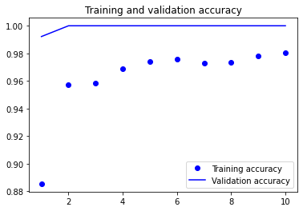

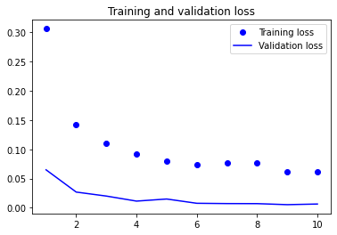

```python
accuracy = history.history['accuracy']
val_accuracy = history.history['val_accuracy']
loss = history.history['loss']
val_loss = history.history['val_loss']
epochs = range(1, len(accuracy) + 1)
plt.plot(epochs, accuracy, 'bo', label='Training accuracy')
plt.plot(epochs, val_accuracy, 'b', label='Validation accuracy')
plt.title('Training and validation accuracy')
plt.legend()
plt.figure()
plt.plot(epochs, loss, 'bo', label='Training loss')
plt.plot(epochs, val_loss, 'b', label='Validation loss')
plt.title('Training and validation loss')
plt.legend()
plt.show()
```

Matriz de confusión sobre los datos de validación.

```
Evaluación accuracy: 100.00%
```

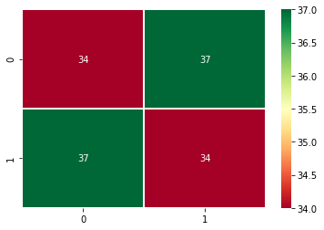

```python
validation_generator.reset()

# Evaluación del modelo en la muestra de Validation -> muestra total
scores = cnn_Xception_1.evaluate(validation_generator)
print("%s%s: %.2f%%" % ("Evaluación ", cnn_Xception_1.metrics_names[1], scores[1]*100))

# model_tf_hub.metrics_names  -> [0]: loss [1]: accuracy

# predicciones de las instancias
predictions_proba = cnn_Xception_1.predict(validation_generator)
predictions_class = np.where(predictions_proba > 0.5, 1, 0)

# matriz de confusión
sns.heatmap(confusion_matrix(validation_generator.labels, predictions_class), cmap="RdYlGn", linewidths=.5,
            annot = True,  fmt='.0f', cbar=True)

plt.show()
```

Matriz de confusión sobre los datos de test.

```
Evaluación accuracy: 98.97%
```

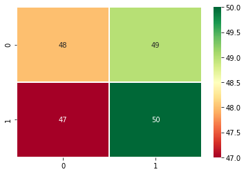

```python
# Evaluación del modelo en la muestra de Validation -> muestra total

test_generator.reset()

scores = cnn_Xception_1.evaluate(test_generator)
scores
print("%s%s: %.2f%%" % ("Evaluación ", cnn_Xception_1.metrics_names[1], scores[1]*100))

# model_tf_hub.metrics_names  -> [0]: loss [1]: accuracy

# predicciones de las instancias
predictions_proba = cnn_Xception_1.predict(test_generator)
predictions_class = np.where(predictions_proba >0.5, 1, 0)

#matriz de confusión
sns.heatmap(confusion_matrix(test_generator.labels, predictions_class), cmap="RdYlGn", linewidths=.5,
             annot = True,  fmt='.0f', cbar=True)

plt.show()
```

Obteniéndose un resultado cercano a los datos de validación, por lo que podemos descartar el sobreajuste. Además, es el modelo más preciso, con un porcentaje de acierto de prácticamente el 99%.